# HW6 R Functions

Joshua Chun (A17812847)

2026-04-17

## Q1

The type of object returned from read.pdb() is a list object, which returns a list containing components like atom data, coordinates, etc.

## Q2

This function extracts a subset of the PDB structure, like selecting chain A or selecting alpha carbons only. For example, chain=”A” selects chain A, or doing elety=”CA” selects alpha carbons only.

## Q3

The parameter sse = NULL will turn off the rectangles in the plots. They represent the secondary structure elements like the alpha helices and the beta sheets.

## Q4

An overlay plot (single combined line plot) would be a better plot to compare proteins. We could plot all the B-factors and use different colors for a direct comparison across proteins.

## Q5

The proteins s2 and s3 are the most similar because they cluster together at the lowest height in the dendrogram. This indicates they have the smallest distance between their B-factor profiles. Similarity is shown using a distance matrix (dist) followed by hierarchical clustering (hclust), where lower linkage height shows greater similarity.

## Q6

```r
library(bio3d)
```

```r
s1 <- read.pdb("4AKE")
```

```
##   Note: Accessing on-line PDB file
```

```r
s2 <- read.pdb("1AKE")
```

```
##   Note: Accessing on-line PDB file
##    PDB has ALT records, taking A only, rm.alt=TRUE
```

```r
s3 <- read.pdb("1E4Y")
```

```
##   Note: Accessing on-line PDB file
```

```r
s1.chainA <- trim.pdb(s1, chain = "A", elety = "CA")
s2.chainA <- trim.pdb(s2, chain = "A", elety = "CA")
s3.chainA <- trim.pdb(s3, chain = "A", elety = "CA")

s1.b <- s1.chainA$atom$b
s2.b <- s2.chainA$atom$b
s3.b <- s3.chainA$atom$b
```

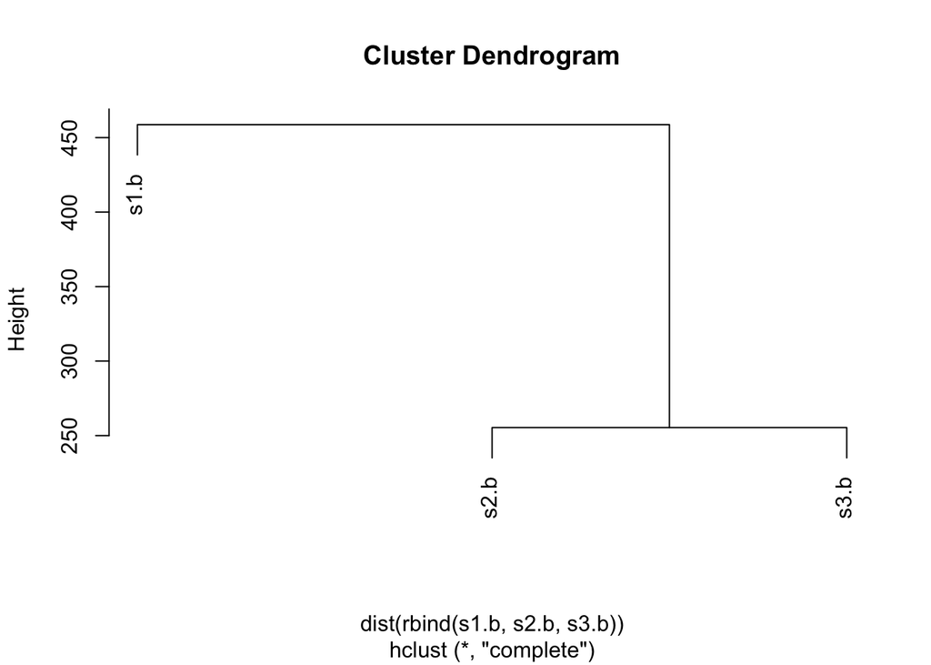

```r
hc <- hclust(dist(rbind(s1.b, s2.b, s3.b)))
plot(hc)
```

```r
analyze_protein <- function(pdb_id) {
  pdb <- read.pdb(pdb_id)
  protein <- trim.pdb(pdb, chain = "A", elety = "CA")
  b <- protein$atom$b

# Input:
# pdb_id = a PDB ID such as "4AKE"

# What this function does:
# This function reads a protein PDB structure, selects chain A CA atoms, extracts the B-factors, and makes a B-factor plot.

# Output:
# Returns a vector of B-factor values and displays a plot.

  plotb3(b, sse = protein, typ = "l", ylab = "Bfactor",
         main = paste("B-factor plot for", pdb_id))

  return(b)
}
```

```r
analyze_protein("4AKE")
```

```
##   Note: Accessing on-line PDB file
```

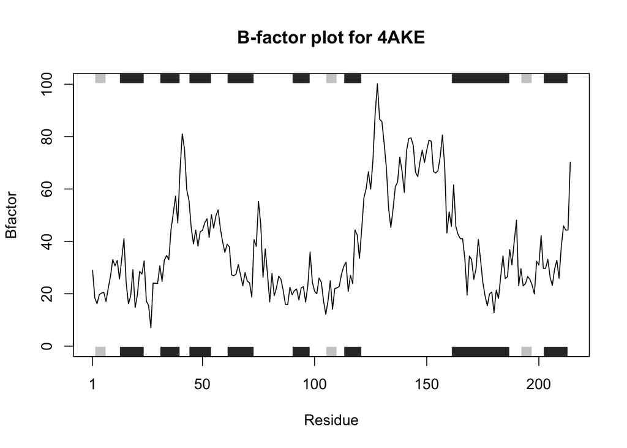

```
##   [1]  29.02  18.44  16.20  19.67  20.26  20.55  17.05  22.13  26.71  33.05
##  [11]  30.66  32.73  25.61  33.19  41.03  24.09  16.18  19.14  29.19  14.79
##  [21]  19.63  28.54  27.49  32.56  17.13  15.50   6.98  24.07  24.00  23.94
##  [31]  30.70  24.70  32.84  34.60  33.01  44.60  50.74  57.32  47.04  67.13
##  [41]  81.04  75.20  59.68  55.63  45.12  39.04  44.31  38.21  43.70  44.19
##  [51]  47.00  48.67  41.54  50.22  45.07  49.77  52.04  44.82  39.75  35.79
##  [61]  38.92  37.93  27.18  26.86  27.53  31.16  27.08  23.03  28.12  24.78
##  [71]  24.22  18.69  40.67  38.08  55.26  46.29  26.25  37.14  27.50  16.86
##  [81]  27.76  19.27  22.22  26.70  25.52  21.22  15.90  15.84  22.44  19.61
##  [91]  21.23  21.79  17.64  22.19  22.73  16.80  23.25  35.95  24.42  20.96
## [101]  20.00  25.99  24.39  17.19  12.16  17.35  24.97  14.08  22.01  22.26
## [111]  22.78  27.47  30.49  32.02  20.90  27.03  23.84  44.37  42.47  33.48
## [121]  44.56  56.67  60.18  66.62  59.95  70.81  88.63 100.11  86.60  85.80
## [131]  77.48  68.13  52.66  45.34  52.43  60.90  62.64  72.19  66.75  58.73
## [141]  74.57  79.29  79.53  76.58  66.40  64.76  70.48  74.84  70.11  74.82
## [151]  78.61  78.24  66.70  66.10  67.01  72.28  80.64  68.54  43.23  51.24
## [161]  45.72  61.60  45.61  42.57  41.03  41.02  33.34  19.48  34.38  33.11
## [171]  25.48  29.68  40.71  32.91  24.41  19.20  15.43  19.93  20.66  12.72
## [181]  21.40  18.21  26.68  34.50  25.77  26.52  36.85  31.05  39.84  48.03
## [191]  23.04  29.57  23.00  23.80  26.59  25.49  23.25  19.89  32.37  30.97
## [201]  42.16  29.64  29.69  33.15  26.38  23.17  29.35  32.80  25.92  38.01
## [211]  45.95  44.26  44.35  70.26
```